# Procesando datos con `{tidyverse}` - Parte I

Módulo 3 - Importación, select() y filter()

Pablo Tiscornia

[Estación R](https://estacion-r.com/)

2026-03-10

# Bienvenidos y bienvenidas

## Contacto con Estación R

#### [Slack](https://estacion-r.slack.com/)

#### [Web](https://estacion-r.com)

#### Correo

#### [Mastodon](https://botsin.space/@r_tips)

#### [X](https://twitter.com/estacion_erre)

#### [LinkedIn](https://www.linkedin.com/company/estacion-r/)

#### [Instagram](https://instagram.com/estacion_ere)

## ¿Qué vimos hasta ahora?

✅ La **EPH**: qué mide, cómo se estructura, cuestionarios

✅ Conceptos básicos de **R**: valores, vectores, funciones, objetos

✅ Cómo usar la **IA como asistente** para aprender R

✅ **RStudio**: consola, scripts, entorno

## Hoja de Ruta - Hoy

📦 `{tidyverse}`: un universo de paquetes

📥 **Importar datos**: la EPH en R

🔗 La **pipa** (`|>`)

🔧 `select()` - elegir columnas

🔧 `filter()` - filtrar filas

# Paquetes en R

## ¿Qué son los paquetes?

R viene con funciones básicas (`c()`, `mean()`, `class()`…), pero su verdadero poder está en los **paquetes**.

Un **paquete** es un conjunto de funciones que alguien creó para resolver un problema específico.

Pensalo como una **caja de herramientas**: R es el taller, y los paquetes son cajas con herramientas especializadas que podemos agregar.

## ¿Cómo se usan los paquetes?

**Paso 1:** Instalar (una sola vez, como descargar una app):

```r
install.packages("nombre_del_paquete")
```

**Paso 2:** Cargar (cada vez que abrimos R, como abrir la app):

```r
library(nombre_del_paquete)
```

> Primero se **instala** (una vez), después se **carga** (cada sesión).

# `{tidyverse}`

## ¿Qué es `{tidyverse}`?

- Una **colección de paquetes** de R.
- Comparten una filosofía acerca de los datos y la programación en R (“*tidy*” - *ordenado*).
- Tienen una **coherencia** para ser utilizados en conjunto.
- Orientado a ser leído y escrito **por y para seres humanos**.
- Una **comunidad**, basada en los principios del código abierto y trabajo colaborativo.

## ¿Qué es `{tidyverse}`?

[figure not shown]

## `{tidyverse}` - Instalación y carga

- Instalación (una sola vez):

```r
install.packages("tidyverse")
```

- Cargo el paquete (cada vez que abro R):

```r
library(tidyverse)
```

# Importar datos: la EPH en R

## ¿Cómo traemos datos a R?

Hasta ahora creamos datos “a mano” con `c()` y `data.frame()`.

Pero en la práctica, los datos **ya existen**: en archivos `.csv`, `.xlsx`, bases de datos…

Hoy vamos a importar datos **reales** de la EPH.

## Opción 1: Descargar desde INDEC

1. Ir a la [página del INDEC](https://www.indec.gob.ar/indec/web/Institucional-Indec-BasesDeDatos)
2. Buscar “Encuesta Permanente de Hogares” > **Bases trimestrales**
3. Descargar el archivo `.zip` del trimestre deseado
4. Descomprimir y usar `read.csv()` o `read_csv()` para leer el archivo `.txt`

## Opción 1: Importar con `read.csv()`

```r
# Opción con R base
eph_ind <- read.csv("datos/usu_individual_T124.txt",
                     sep = ";")
```

```r
# Opción con tidyverse (readr) - más rápida
library(readr)

eph_ind <- read_csv2("datos/usu_individual_T124.txt")
```

## Opción 2: El paquete `{eph}`

El paquete `{eph}` fue creado por la comunidad R argentina para facilitar el trabajo con la EPH.

```r
# Instalar (una sola vez)
install.packages("eph")
```

```r
# Descargar datos directamente desde R
library(eph)

eph_ind <- get_microdata(year = 2024,
                         trimester = 1,
                         type = "individual")
```

## Nuestros datos para hoy

```r
library(readr)
eph_ind <- read_csv("datos/eph_individual.csv")
```

```r
# ¿Cuántas filas y columnas?
dim(eph_ind)
```

```
[1] 46050   235
```

> **46.050 personas** y **235 variables**. Cada fila es una persona encuestada.

## Explorando la base

```r
# ¿Qué columnas tiene? (mostramos las primeras 20)
head(colnames(eph_ind), 20)
```

```
 [1] "CODUSU"     "ANO4"       "TRIMESTRE"  "NRO_HOGAR"  "COMPONENTE"
 [6] "H15"        "REGION"     "MAS_500"    "AGLOMERADO" "PONDERA"
[11] "CH03"       "CH04"       "CH05"       "CH06"       "CH07"
[16] "CH08"       "CH09"       "CH10"       "CH11"       "CH12"
```

`head()` nos muestra los **primeros elementos** de un resultado (acá, las primeras 20 columnas).

> Los nombres de las variables son **códigos** (CH04, CH06, ESTADO…). Para entender qué significan, necesitamos el [**diseño de registro**](https://www.indec.gob.ar/ftp/cuadros/menusuperior/eph/EPH_registro_1t19.pdf) de la EPH.

## Variables clave de la EPH

| Variable | Significado | Valores |
| --- | --- | --- |
| `CH04` | **Sexo** | 1=Varón, 2=Mujer |
| `CH06` | **Edad** | Años cumplidos |
| `ESTADO` | **Condición de actividad** | 1=Ocupado, 2=Desocupado, 3=Inactivo |
| `CAT_OCUP` | **Categoría ocupacional** | 1=Patrón, 2=Cta. propia, 3=Asalariado |
| `NIVEL_ED` | **Nivel educativo** | 1 a 7 (de primaria incompleta a superior completa) |
| `P21` | **Ingreso ocupación principal** | En pesos |
| `REGION` | **Región estadística** | 1=GBA, 40=NOA, 41=NEA, 42=Cuyo, 43=Pampeana, 44=Patagonia |

# La pipa

## Un operador llamado `pipa`

```r
base_de_datos |>
  funcion1 |>
  funcion2 |>
  funcion3
```

[figure not shown]

## Un operador llamado `pipa`

- Pipa de **R base**: `|>` (atajo: `Ctrl + Shift + M`)
- Pipa de **{magrittr}**: `%>%`

> Ambas hacen lo mismo: **pasan el resultado de la izquierda como primer argumento de la función de la derecha**

## Ejemplo sin pipa

```r
datos <- data.frame(nombre = c("Pirulanzo", "Rodogovia", "Rodogovia", "Rodogovia"),
                    edad = c(23, 12, 87, 32))

datos
```

```
     nombre edad
1 Pirulanzo   23
2 Rodogovia   12
3 Rodogovia   87
4 Rodogovia   32
```

## Ejemplo sin pipa

- Quiero calcular qué proporción de personas se llaman *Rodogovia*
- Antes (*sin el pipe*):

```r
round(prop.table(table(datos$nombre)), digits = 1)
```

```
Pirulanzo Rodogovia
      0.2       0.8
```

> Se lee de adentro hacia afuera… 🤯

## Ejemplo con pipa

- Después (*con el pipe*):

```r
datos$nombre |>
  table() |>
  prop.table() |>
  round(digits = 1)
```

```
Pirulanzo Rodogovia
      0.2       0.8
```

> Se lee de arriba hacia abajo, paso a paso ✨

# `select()`

## Funciones del paquete `{dplyr}`

| **Función** | **Acción** |
| --- | --- |
| **`select()`** | *selecciona o descarta columnas* |
| **`filter()`** | *selecciona filas* |
| `mutate()` | *crea / edita variables* |
| `rename()` | *renombra variables* |
| `group_by()` | *segmenta en función de una variable* |
| `summarize()` | *genera una tabla de resumen* |

> Hoy nos enfocamos en **select()** y **filter()**. El resto, la semana que viene.

## `select()` - Elige o descarta columnas

- La función tiene la siguiente estructura:

```r
base_de_datos |>
  select(variable1, variable2)
```

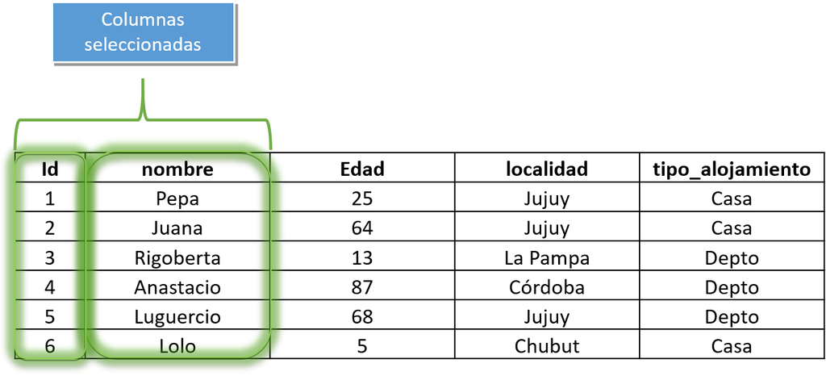

## Caso práctico

- **Pedido:** La directora de investigación nos pidió analizar la **edad** y el **sexo** de la población encuestada, junto con su **condición de actividad**.
- Variables de trabajo:
  - `CH04` (sexo)
  - `CH06` (edad)
  - `ESTADO` (condición de actividad)

## Caso práctico - Selecciono columnas

```r
eph_ind |>
  select(CH04, CH06, ESTADO)
```

```
# A tibble: 46,050 × 3
    CH04  CH06 ESTADO
   <dbl> <dbl>  <dbl>
 1     2    86      3
 2     1    68      1
 3     1    20      2
 4     2    75      3
 5     2    41      1
 6     1    42      1
 7     2    20      3
 8     1    14      3
 9     1    29      1
10     2    27      2
# ℹ 46,040 more rows
```

## Caso práctico - Guardo en un objeto

```r
eph_sel <- eph_ind |>
  select(CH04, CH06, ESTADO)
```

```r
colnames(eph_sel)
```

```
[1] "CH04"   "CH06"   "ESTADO"
```

> Ahora `eph_sel` tiene solo 3 columnas, en vez de las 235 originales.

## `select()` - por posición

```r
# Selecciono las columnas 1, 12 y 14 (CODUSU, CH04, CH06)
eph_ind |>
  select(1, 12, 14) |>
  colnames()
```

```
[1] "CODUSU" "CH04"   "CH06"
```

```r
# Selecciono un rango de columnas consecutivas
eph_ind |>
  select(11:16) |>
  colnames()
```

```
[1] "CH03" "CH04" "CH05" "CH06" "CH07" "CH08"
```

## `select()` - Por patrones de texto

**Trío muy útil:**

- `starts_with()` –> *empieza con…*
- `ends_with()` –> *termina con…*
- `contains()` –> *contiene…*

## `select()` + `starts_with()`

```r
# Todas las variables del cuestionario de Hogar (empiezan con "CH")
eph_ind |>
  select(starts_with("CH")) |>
  colnames()
```

```
 [1] "CH03"     "CH04"     "CH05"     "CH06"     "CH07"     "CH08"
 [7] "CH09"     "CH10"     "CH11"     "CH12"     "CH13"     "CH14"
[13] "CH15"     "CH15_COD" "CH16"     "CH16_COD"
```

## `select()` + `ends_with()`

```r
# Variables que terminan en "_COD" (códigos de clasificación)
eph_ind |>
  select(ends_with("_COD")) |>
  colnames()
```

```
[1] "CH15_COD"  "CH16_COD"  "PP04B_COD" "PP04D_COD" "PP11B_COD" "PP11D_COD"
```

## `select()` + `contains()`

```r
# Variables que contienen "ING" (relacionadas a ingresos)
eph_ind |>
  select(contains("ING")) |>
  colnames()
```

```
character(0)
```

## La combinación final

Se pueden combinar todas las formas:

```r
eph_ind |>
  select(CODUSU, CH04, CH06, starts_with("P21"), ESTADO, REGION) |>
  colnames()
```

```
[1] "CODUSU" "CH04"   "CH06"   "P21"    "ESTADO" "REGION"
```

# Ejercitación

## Ejercitación `select()`

Usando la base de la EPH:

1. Seleccionar las variables `CH04` (sexo), `CH06` (edad) y `P21` (ingreso) y guardar en un objeto.
2. Seleccionar **todas las variables que empiecen con “CH”** y guardar en otro objeto. ¿Cuántas hay?
3. Seleccionar las columnas 1 a 5 y verificar con `colnames()`.

# `filter()`

## `filter()` - Define filas en base a una condición

- La función tiene la siguiente estructura:

```r
base_de_datos |>
  filter(condicion)
```

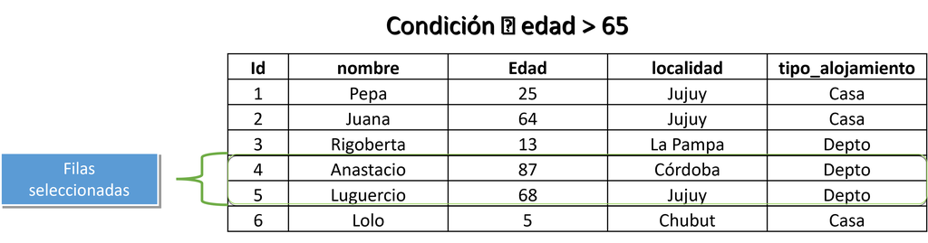

## Caso práctico

- Para un informe de empleo, necesitamos quedarnos solo con la **población ocupada** (`ESTADO == 1`).
- Primero, chequeamos los valores de la variable:

```r
unique(eph_ind$ESTADO)
```

```
[1] 3 1 2 4 0
```

> Recordar: 1=Ocupado, 2=Desocupado, 3=Inactivo, 4=Menor de 10 años

## Caso práctico - Aplico filtro

```r
eph_ocupados <- eph_ind |>
  filter(ESTADO == 1)
```

- Chequeo que funcionó:

```r
unique(eph_ocupados$ESTADO)
```

```
[1] 1
```

```r
# ¿Cuántas personas ocupadas hay?
nrow(eph_ocupados)
```

```
[1] 20325
```

## Operadores de comparación

| Condición | Acción |
| --- | --- |
| `==` | *igual* |
| `%in%` | *incluye* |
| `!=` | *distinto* |
| `>` | *mayor que* |
| `<` | *menor que* |
| `>=` | *mayor o igual que* |
| `<=` | *menor o igual que* |

| Operador | Descripción |
| --- | --- |
| `&` | *y* - Ambas condiciones se cumplen |
| `\\|` | *o* - Una u otra condición se cumple |

## Caso práctico - Filtro numérico

- Queremos analizar a la **población mayor de 65 años**:

```r
eph_mayores <- eph_ind |>
  filter(CH06 > 65)

nrow(eph_mayores)
```

```
[1] 5744
```

## Caso práctico - Múltiples condiciones

```r
eph_mujeres_ocup <- eph_ind |>
  filter(CH04 == 2 & ESTADO == 1)

nrow(eph_mujeres_ocup)
```

```
[1] 9112
```

## Caso práctico - Operador `%in%`

- Queremos analizar solo **GBA y Patagonia** (`REGION` 1 y 44):

```r
eph_gba_pat <- eph_ind |>
  filter(REGION %in% c(1, 44))

table(eph_gba_pat$REGION)
```

```
   1   44
7051 5527
```

> `%in%` es más prolijo que escribir `REGION == 1 | REGION == 44`, especialmente cuando son varias categorías.

## Novedad: `filter_out()`

Desde febrero 2026, dplyr incluye `filter_out()`: el complemento de `filter()`.

- `filter()` = **me quedo con** las filas que cumplen la condición
- `filter_out()` = **saco** las filas que cumplen la condición

```r
# Estas dos líneas hacen lo mismo:
eph_ind |> filter(ESTADO != 4)

eph_ind |> filter_out(ESTADO == 4)
```

> Para usarlo, actualizar dplyr: `install.packages("dplyr")`

# Combinando `select()` + `filter()`

## `select()` + `filter()`

```r
eph_ind |>
  select(CH04, CH06,
         ESTADO, P21)
```

```
# A tibble: 46,050 × 4
    CH04  CH06 ESTADO    P21
   <dbl> <dbl>  <dbl>  <dbl>
 1     2    86      3      0
 2     1    68      1 150000
 3     1    20      2      0
 4     2    75      3      0
 5     2    41      1 250000
 6     1    42      1 650000
 7     2    20      3      0
 8     1    14      3      0
 9     1    29      1 280000
10     2    27      2      0
# ℹ 46,040 more rows
```

## `select()` + `filter()`

```r
eph_ind |>
  select(CH04, CH06,
         ESTADO, P21) |>
  filter(ESTADO == 1)
```

```
# A tibble: 20,325 × 4
    CH04  CH06 ESTADO    P21
   <dbl> <dbl>  <dbl>  <dbl>
 1     1    68      1 150000
 2     2    41      1 250000
 3     1    42      1 650000
 4     1    29      1 280000
 5     2    31      1  50000
 6     1    33      1 300000
 7     2    63      1 250000
 8     1    61      1     -9
 9     1    25      1 180000
10     1    51      1     -9
# ℹ 20,315 more rows
```

> La **pipa** nos permite encadenar operaciones paso a paso 🔗

## Un análisis más completo

```r
# Mujeres ocupadas de GBA, con sus ingresos
eph_ind |>
  select(CH04, CH06, ESTADO, REGION, P21) |>
  filter(ESTADO == 1,
         CH04 == 2,
         REGION == 1,
         P21 > 0)
```

```
# A tibble: 1,043 × 5
    CH04  CH06 ESTADO REGION    P21
   <dbl> <dbl>  <dbl>  <dbl>  <dbl>
 1     2    38      1      1 400000
 2     2    29      1      1 380000
 3     2    31      1      1 180000
 4     2    56      1      1 120000
 5     2    33      1      1 100000
 6     2    70      1      1 100000
 7     2    38      1      1  72000
 8     2    33      1      1 320000
 9     2    32      1      1  78000
10     2    33      1      1  30000
# ℹ 1,033 more rows
```

# Ejercitación

## Ejercitación `select()` + `filter()`

1. Crear un objeto con las variables `CH04`, `CH06`, `NIVEL_ED` y `ESTADO`. Filtrar solo la **población inactiva** (`ESTADO == 3`).
2. Del objeto anterior, ¿cuántas personas inactivas hay? (*tip: `nrow()`*)
3. Crear un objeto con **varones mayores de 18 años** (`CH04 == 1` y `CH06 > 18`), seleccionando las variables `CH06`, `ESTADO` y `P21`.
4. **Desafío:** Filtrar la población **ocupada de la región Pampeana** (`REGION == 43`) que tenga un ingreso (`P21`) **mayor a 0**. ¿Cuántas personas son?

# Para la semana que viene…

🔧 `mutate()` + `case_when()` - crear y recodificar variables

🔧 `summarise()` - resumir información

🔧 `group_by()` - operar por grupos

🎯 Combinando todo: **tidyverse en acción** con la EPH

## ¡Gracias!

📧 pablotiscornia@estacion-r.com

💬 [Slack de Estación R](https://estacion-r.slack.com/)